# Report

Khai báo các thư viện sử dụng

```r
library(dplyr)
library(statsr)
```

1. Thông tin của tập dữ liệu và hiển thị sơ bộ

#Nguồn tham khảo: Tên: High School and Beyond survey Tổ chức sở hữu: OpenIntro Link: https://www.openintro.org/data/index.php?data=hsb2 Tổ chức thu thập dữ liệu: Đại học California tại Los Angeles (UCLA) Link của tổ chức thu thập dữ liệu: UCLA Academic Technology Services, http://www.ats.ucla.edu/stat/data/hsb2.csv File dữ liệu: hsb2.csv

# Giới thiệu

Hai trăm quan sát được lấy mẫu ngẫu nhiên từ cuộc khảo sát Trung học, một cuộc Nghiên cứu được thực hiện trên học sinh của Trung tâm Thống kê Giáo dục Quốc gia.

```r
# Hiển thị sơ bộ
students_scores <- read.csv("hsb2.csv")
students_scores
```

[output not shown]

[output cut: 387 more lines]

Các cột điểm read, write, math, science, socst dưới đây đều tính theo cột điểm 100

| Biến | Mô tả |
| --- | --- |
| `id` | Mã số học sinh |
| `gender` | Giới tính gồm 2 loại: male và female |
| `race` | Chủng tộc gồm 4 loại: african american, asian, hispanic và white |
| `ses` | Điều kiện kinh tế của học sinh gồm 3 loại: low, middle và high |
| `schtyp` | Loại trường gồm 2 loại: public and private |
| `prog` | Chương trình giảng dạy gồm 3 loại: general, academic, and vocational |
| `read` | Điểm đọc |
| `write` | Điểm viết |
| `math` | Điểm toán |
| `science` | Điểm khoa học |
| `socst` | Điểm công tác xã hội |

```r
glimpse(students_scores)
```

```
## Rows: 200
## Columns: 11
## $ id      <int> 70, 121, 86, 141, 172, 113, 50, 11, 84, 48, 75, 60, 95, 104...
## $ gender  <chr> "male", "female", "male", "male", "male", "male", "male", "...
## $ race    <chr> "white", "white", "white", "white", "white", "white", "afri...
## $ ses     <chr> "low", "middle", "high", "high", "middle", "middle", "middl...
## $ schtyp  <chr> "public", "public", "public", "public", "public", "public",...
## $ prog    <chr> "general", "vocational", "general", "vocational", "academic...
## $ read    <int> 57, 68, 44, 63, 47, 44, 50, 34, 63, 57, 60, 57, 73, 54, 45,...
## $ write   <int> 52, 59, 33, 44, 52, 52, 59, 46, 57, 55, 46, 65, 60, 63, 57,...
## $ math    <int> 41, 53, 54, 47, 57, 51, 42, 45, 54, 52, 51, 51, 71, 57, 50,...
## $ science <int> 47, 63, 58, 53, 53, 63, 53, 39, 58, 50, 53, 63, 61, 55, 31,...
## $ socst   <int> 57, 61, 31, 56, 61, 61, 61, 36, 51, 51, 61, 61, 71, 46, 56,...
```

2. Phân tích tổng quan các biến trong tập dữ liệu (EDA)

Các biến phân loại gồm:

| Biến | Mô tả |
| --- | --- |
| `gender` | Giới tính gồm 2 loại: male và female |
| `race` | Chủng tộc gồm 4 loại: african american, asian, hispanic và white |
| `ses` | Điều kiện kinh tế của học sinh gồm 3 loại: low, middle và high |
| `schtyp` | Loại trường gồm 2 loại: public and private |
| `prog` | Chương trình giảng dạy gồm 3 loại: general, academic, and vocational |

Vẽ biểu đồ cho các biến phân loại:

```r
# Biểu đồ cho cột gender
gender_data <- students_scores %>%
  count(students_scores$gender)
gender_data
```

```
##   students_scores$gender   n
## 1                 female 109
## 2                   male  91
```

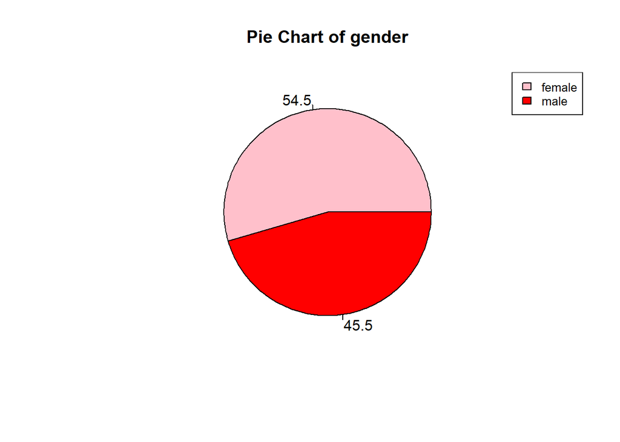

```r
piepercent<- round(100*gender_data$n/sum(gender_data$n), 1)
colors_data <- c("pink","red")
pie(gender_data$n, labels = piepercent, col = colors_data, main="Pie Chart of gender")
legend("topright", gender_data$`students_scores$gender`,
       cex = 0.8, fill = colors_data)
```

```r
# Biểu đồ cho cột race
race_data <- students_scores %>%
  count(students_scores$race)
race_data
```

```
##   students_scores$race   n
## 1     african american  20
## 2                asian  11
## 3             hispanic  24
## 4                white 145
```

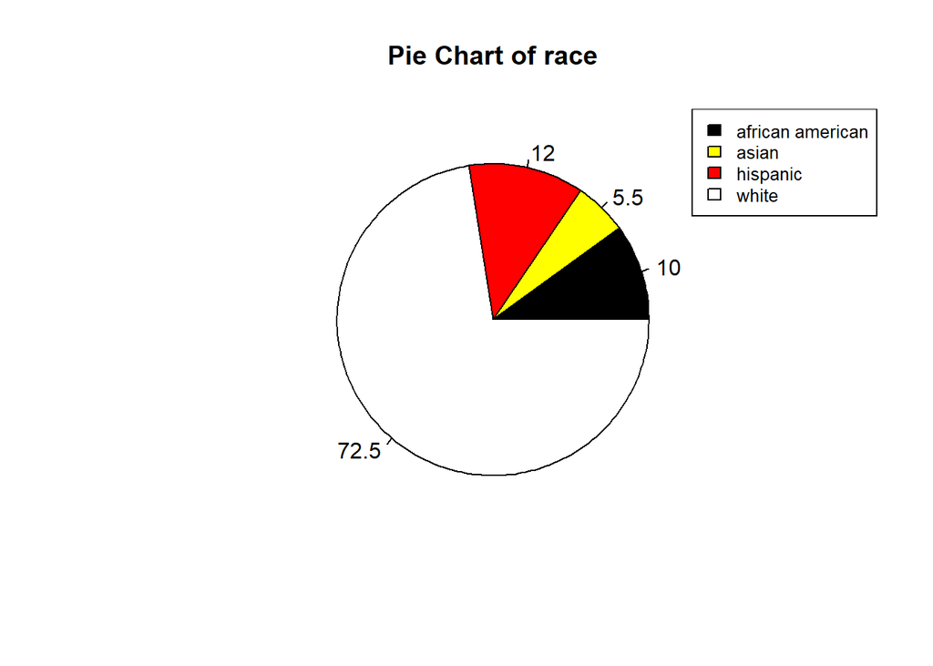

```r
piepercent<- round(100*race_data$n/sum(race_data$n), 1)
colors_data <- c("black","yellow","red","white")
pie(race_data$n, labels = piepercent, col = colors_data, main="Pie Chart of race")
legend("topright", race_data$`students_scores$race`,
       cex = 0.8, fill = colors_data)
```

```r
#Biểu đồ cho cột ses
ses_data <- students_scores %>%
  count(students_scores$ses)
ses_data
```

```
##   students_scores$ses  n
## 1                high 58
## 2                 low 47
## 3              middle 95
```

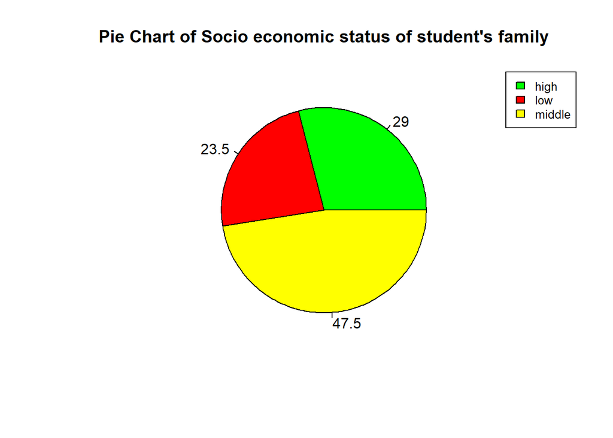

```r
piepercent<- round(100*ses_data$n/sum(ses_data$n), 1)
colors_data <- c("green","red","yellow")
pie(ses_data$n, labels = piepercent, col = colors_data, main="Pie Chart of Socio economic status of student's family")
legend("topright", ses_data$`students_scores$ses`,
       cex = 0.8, fill = colors_data)
```

```r
#Biểu đồ cho cột schtyp
schtyp_data <- students_scores %>%
  count(students_scores$schtyp)
schtyp_data
```

```
##   students_scores$schtyp   n
## 1                private  32
## 2                 public 168
```

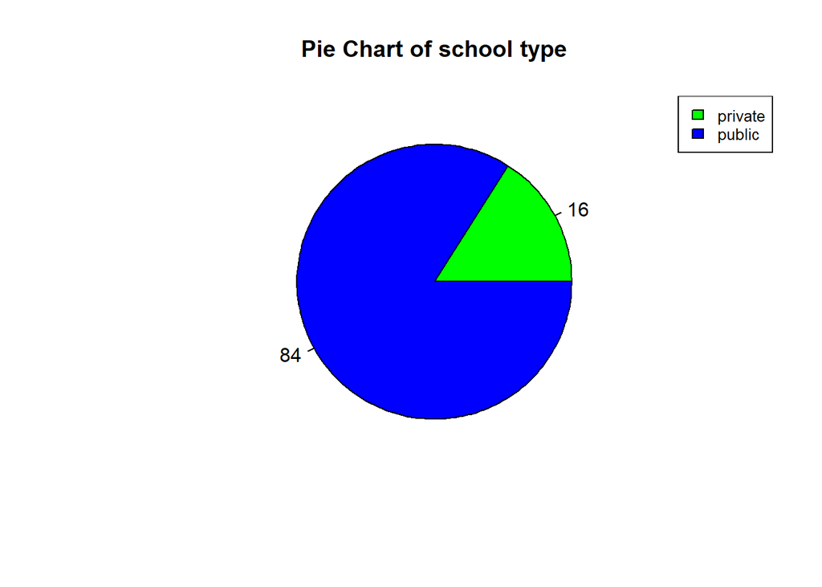

```r
piepercent<- round(100*schtyp_data$n/sum(schtyp_data$n), 1)
colors_data <- c("green","blue")
pie(schtyp_data$n, labels = piepercent, col = colors_data, main="Pie Chart of school type")
legend("topright", schtyp_data$`students_scores$schtyp`,
       cex = 0.8, fill = colors_data)
```

```r
#Biểu đồ cho cột prog
prog_data <- students_scores %>%
  count(students_scores$prog)
prog_data
```

```
##   students_scores$prog   n
## 1             academic 105
## 2              general  45
## 3           vocational  50
```

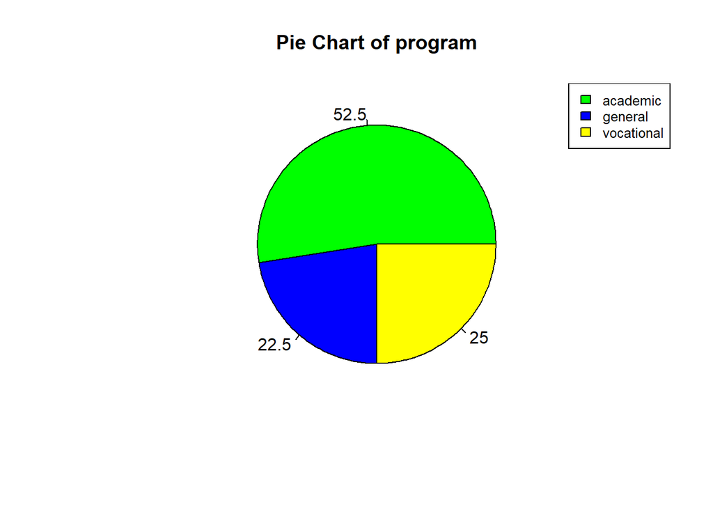

```r
piepercent<- round(100*prog_data$n/sum(prog_data$n), 1)
colors_data <- c("green","blue","yellow")
pie(prog_data$n, labels = piepercent, col = colors_data, main="Pie Chart of program")
legend("topright", prog_data$`students_scores$prog`,
       cex = 0.8, fill = colors_data)
```

Các biến số gồm:

| Biến | Mô tả |
| --- | --- |
| `read` | Điểm đọc |
| `write` | Điểm viết |
| `math` | Điểm toán |
| `science` | Điểm khoa học |
| `socst` | Điểm công tác xã hội |

Vẽ biểu đồ cho các biến số và tính các summary statistics:

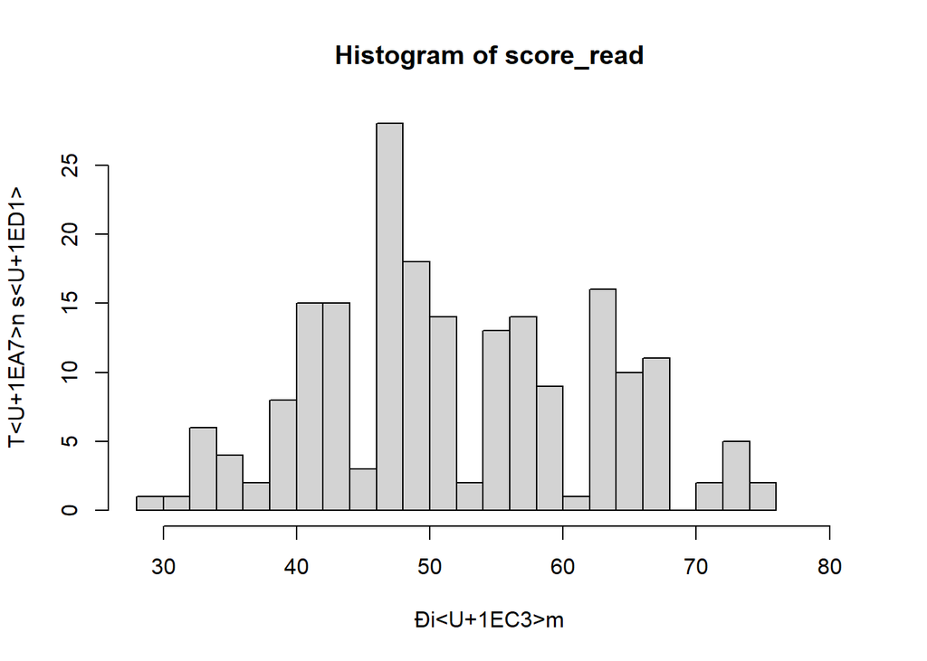

```r
#Biểu đồ cho cột read
read_data <- students_scores %>%
  count(students_scores$read) %>%
  nrow()
hist(students_scores$read,
     include.lowest = TRUE, right = TRUE, breaks = read_data,
     main = paste("Histogram of score_read"),
     xlim = range(min(students_scores$read),max(students_scores$read)+5), ylim = NULL,
     xlab = "Điểm", ylab = "Tần số")
```

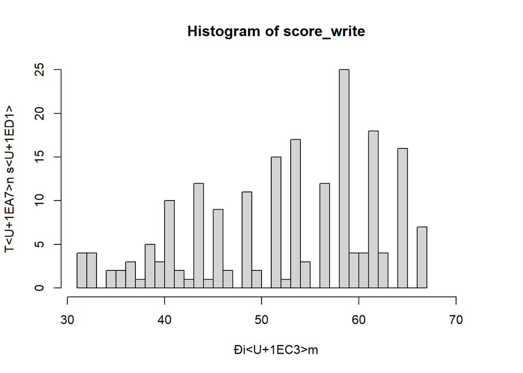

```r
#Biểu đồ cho cột write
write_data <- students_scores %>%
  count(students_scores$write) %>%
  nrow()
hist(students_scores$write,
     include.lowest = TRUE, right = TRUE, breaks = write_data,
     main = paste("Histogram of score_write"),
     xlim = range(min(students_scores$write),max(students_scores$write)+5), ylim = NULL,
     xlab = "Điểm", ylab = "Tần số")
```

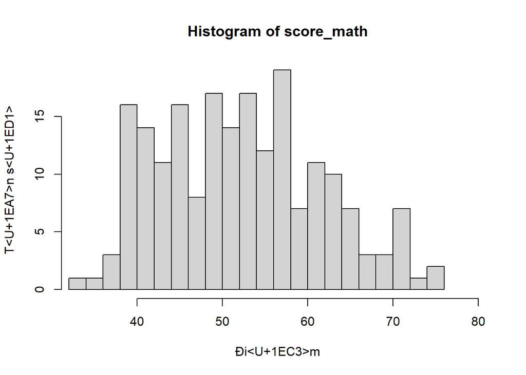

```r
#Biểu đồ cho cột math
math_data <- students_scores %>%
  count(students_scores$math) %>%
  nrow()
hist(students_scores$math,
     include.lowest = TRUE, right = TRUE, breaks = write_data,
     main = paste("Histogram of score_math"),
     xlim = range(min(students_scores$math),max(students_scores$math)+5), ylim = NULL,
     xlab = "Điểm", ylab = "Tần số")
```

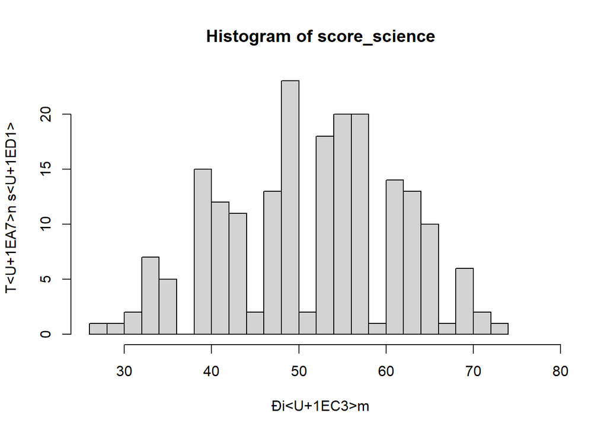

```r
#Biểu đồ cho cột science
science_data <- students_scores %>%
  count(students_scores$science) %>%
  nrow()
hist(students_scores$science,
     include.lowest = TRUE, right = TRUE, breaks = science_data,
     main = paste("Histogram of score_science"),
     xlim = range(min(students_scores$science),max(students_scores$science)+5), ylim = NULL,
     xlab = "Điểm", ylab = "Tần số")
```

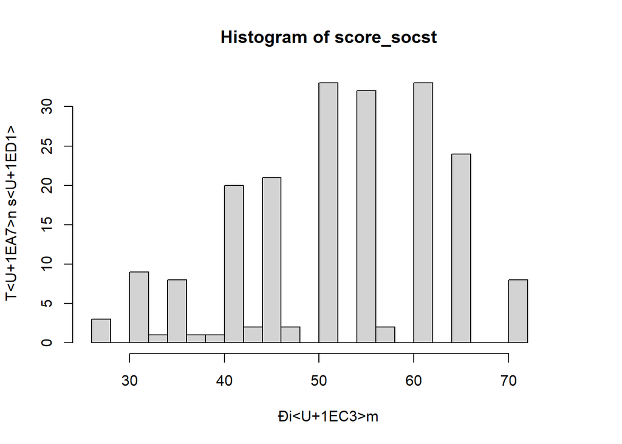

```r
#Biểu đồ cho cột socst
socst_data <- students_scores %>%
  count(students_scores$socst) %>%
  nrow()
hist(students_scores$socst,
     include.lowest = TRUE, right = TRUE, breaks = socst_data,
     main = paste("Histogram of score_socst"),
     xlim = range(min(students_scores$socst),max(students_scores$socst)+5), ylim = NULL,
     xlab = "Điểm", ylab = "Tần số")
```

3. Chọn 3 biến phân loại và 1 biến số: 3 Biến phân loại được chọn là race, schtyp và gender Biến số dùng để phân tích là math

Tính và so sánh kích cỡ hai mẫu chia theo loại trường

```r
students_scores %>%
  count(students_scores$schtyp)
```

```
##   students_scores$schtyp   n
## 1                private  32
## 2                 public 168
```

Tính và so sánh kích cỡ hai mẫu chia theo giới tính

```r
divide_data <- students_scores %>%
  count(students_scores$gender)
divide_data
```

```
##   students_scores$gender   n
## 1                 female 109
## 2                   male  91
```

Do việc chia mẫu dựa trên biến phân loại theo giới tính sẽ có kích thước gần giống nhau nên ta sẽ chọn biến phân loại là giới tính đễ tạo ra hai mẫu.

Biểu đồ thanh (bar chart) của hai mẫu được chia dựa trên biến phân loại giới tính

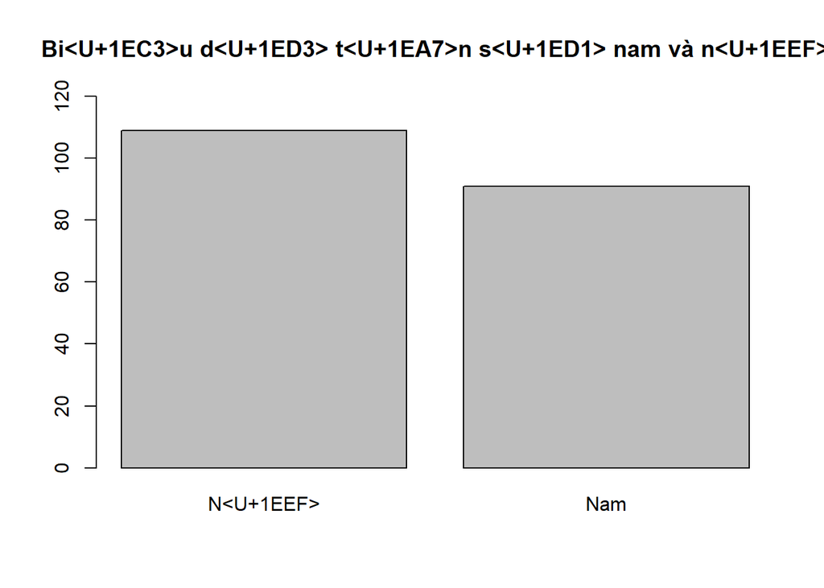

```r
barplot(table(students_scores$gender),ylim=c(0, 120), main="Biểu đồ tần số nam và nữ", names = c("Nữ","Nam"))
```

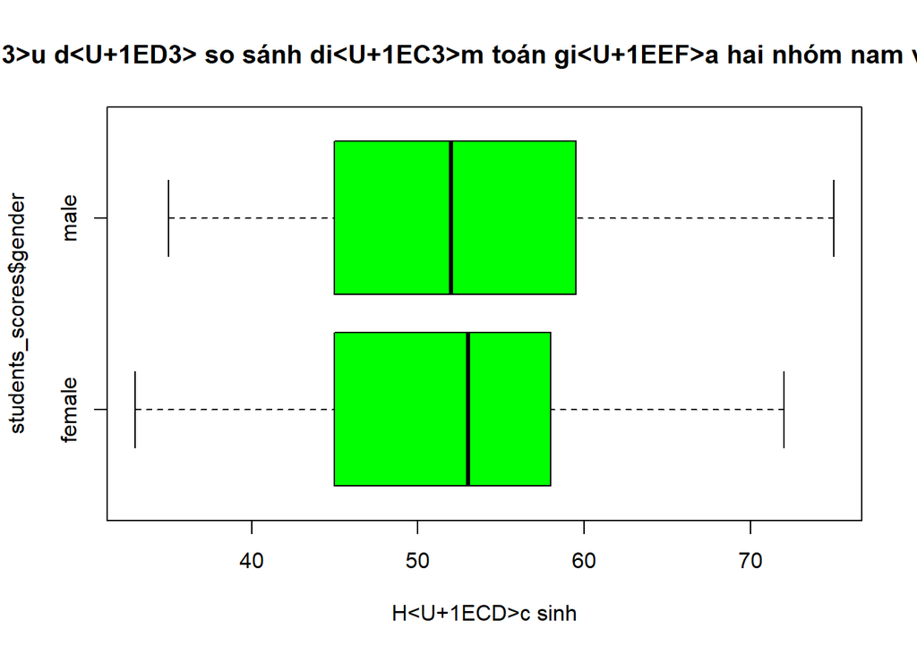

```r
boxplot(students_scores$math ~ students_scores$gender, horizontal=TRUE, main="Biểu đồ so sánh điểm toán giữa hai nhóm nam và nữ", xlab="Học sinh", col = "green")
```

$So$ $sánh$ $thứ$ $nhất$

```r
students_scores %>%
group_by(gender) %>%
summarise(min = min(math), max = max(math),
mean = mean(math), med = median(math),
sd = sd(math),
q1 = quantile(math, probs = 0.25),
q3 = quantile(math, probs = 0.75), .groups = 'drop')
```

```
## # A tibble: 2 x 8
##   gender   min   max  mean   med    sd    q1    q3
##   <chr>  <int> <int> <dbl> <int> <dbl> <dbl> <dbl>
## 1 female    33    72  52.4    53  9.15    45  58
## 2 male      35    75  52.9    52  9.66    45  59.5
```

Ta có $N_{nam}$=91,$mean_{nam}$=52.94505, sd = 9.664784 $N_{nữ}$=109,$mean_{nữ}$=52.39450, sd = 9.151015 Xét hai mẫu có bằng nhau hay không: giả thuyết: $u_{nam}$=$u_{nữ}$ đối thuyết: $u_{nam}$!= $u_{nữ}$ Ta có giá trị kiểm định Z = 0.410958 vậy chỉ khi giá trị -0.410958 < $Z_{a/2}$ < -0.410958 thì hai mẫu bằng nhau và ngược lại

$So$ $sánh$ $thứ$ $hai$

```r
table_Gender_Math<-table(students_scores$gender,students_scores$math)
#barplot(table(students_scores$gender,students_scores$math), main="Biểu đồ #thanh về học sinh đạt điểm toán theo tỉ lệ nam nữ ", xlab = "Tỉ lệ nam #nữ",freq=FALSE)
table_Gender_Math
```

```
##
##          33 35 37 38 39 40 41 42 43 44 45 46 47 48 49 50 51 52 53 54 55 56 57
##   female  1  0  1  1  2  6  4  5  4  2  4  4  1  3  5  4  3  4  7  5  4  6  4
##   male    0  1  0  1  4  4  3  2  3  2  4  4  2  2  5  3  5  2  0  5  1  1  9
##
##          58 59 60 61 62 63 64 65 66 67 68 69 70 71 72 73 75
##   female  3  0  3  3  2  2  3  3  2  2  0  2  0  1  3  0  0
##   male    3  2  2  4  2  3  2  0  2  0  1  0  1  3  0  1  2
```

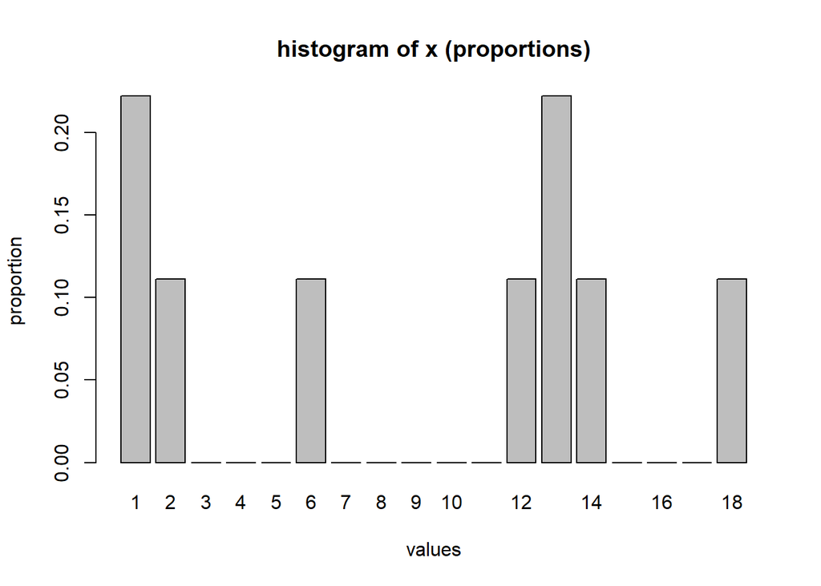

```r
table_Gender_Math<- table(table_Gender_Math)
barplot(height = table(factor(table_Gender_Math, levels=min(table_Gender_Math):max(table_Gender_Math)))/length(table_Gender_Math),
        ylab = "proportion",
        xlab = "values",
        main = "histogram of x (proportions)")
```

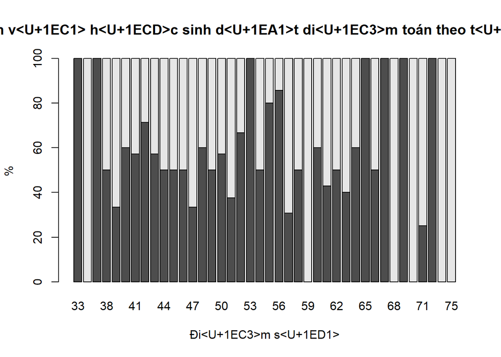

```r
barplot((prop.table(table(students_scores$gender,students_scores$math),margin = 2)*100), main='Biểu đồ thanh về học sinh đạt điểm toán theo tỉ lệ nam nữ ', xlab = "Điểm số", ylab = "%")
```

```r
prop.table(table(students_scores$schtyp,students_scores$math))*100
```

```
##
##            33  35  37  38  39  40  41  42  43  44  45  46  47  48  49  50  51
##   private 0.0 0.0 0.0 0.0 0.0 0.0 0.5 0.5 1.0 0.0 0.5 0.5 0.0 0.5 1.5 1.5 0.5
##   public  0.5 0.5 0.5 1.0 3.0 5.0 3.0 3.0 2.5 2.0 3.5 3.5 1.5 2.0 3.5 2.0 3.5
##
##            52  53  54  55  56  57  58  59  60  61  62  63  64  65  66  67  68
##   private 0.5 0.5 0.5 0.5 0.5 1.5 0.0 0.0 1.0 0.0 0.5 1.5 0.0 0.0 0.0 0.0 0.0
##   public  2.5 3.0 4.5 2.0 3.0 5.0 3.0 1.0 1.5 3.5 1.5 1.0 2.5 1.5 2.0 1.0 0.5
##
##            69  70  71  72  73  75
##   private 1.0 0.0 0.5 0.0 0.0 0.5
##   public  0.0 0.5 1.5 1.5 0.5 0.5
```

```r
table(students_scores$gender,students_scores$math,students_scores$schtyp)
```

```
## , ,  = private
##
##
##          33 35 37 38 39 40 41 42 43 44 45 46 47 48 49 50 51 52 53 54 55 56 57
##   female  0  0  0  0  0  0  0  1  2  0  0  1  0  1  1  1  1  1  1  1  0  1  2
##   male    0  0  0  0  0  0  1  0  0  0  1  0  0  0  2  2  0  0  0  0  1  0  1
##
##          58 59 60 61 62 63 64 65 66 67 68 69 70 71 72 73 75
##   female  0  0  1  0  0  1  0  0  0  0  0  2  0  0  0  0  0
##   male    0  0  1  0  1  2  0  0  0  0  0  0  0  1  0  0  1
##
## , ,  = public
##
##
##          33 35 37 38 39 40 41 42 43 44 45 46 47 48 49 50 51 52 53 54 55 56 57
##   female  1  0  1  1  2  6  4  4  2  2  4  3  1  2  4  3  2  3  6  4  4  5  2
##   male    0  1  0  1  4  4  2  2  3  2  3  4  2  2  3  1  5  2  0  5  0  1  8
##
##          58 59 60 61 62 63 64 65 66 67 68 69 70 71 72 73 75
##   female  3  0  2  3  2  1  3  3  2  2  0  0  0  1  3  0  0
##   male    3  2  1  4  1  1  2  0  2  0  1  0  1  2  0  1  1
```

4. Kiểm định giả thuyết và xây dựng khoảng tin cậy

```r
table_tgender<-table(students_scores$gender,students_scores$math)
t.test(table_tgender)
```

```
##
##  One Sample t-test
##
## data:  table_tgender
## t = 12.095, df = 79, p-value < 2.2e-16
## alternative hypothesis: true mean is not equal to 0
## 95 percent confidence interval:
##  2.08859 2.91141
## sample estimates:
## mean of x
##       2.5
```

```r
table_tschtyp<-table(students_scores$schtyp,students_scores$math)
t.test(table_tschtyp)
```

```
##
##  One Sample t-test
##
## data:  table_tschtyp
## t = 8.5845, df = 79, p-value = 6.305e-13
## alternative hypothesis: true mean is not equal to 0
## 95 percent confidence interval:
##  1.920338 3.079662
## sample estimates:
## mean of x
##       2.5
```

```r
t.test(table_tgender,table_tschtyp)
```

```
##
##  Welch Two Sample t-test
##
## data:  table_tgender and table_tschtyp
## t = 0, df = 142.48, p-value = 1
## alternative hypothesis: true difference in means is not equal to 0
## 95 percent confidence interval:
##  -0.7059298  0.7059298
## sample estimates:
## mean of x mean of y
##       2.5       2.5
```